# Évaluation n°2 — Le second degré

# Évaluation n°2

**Classe :** Première - spécialité **Date :** Lundi 15 Septembre

**Question 1 (1 point).** Soit $a$, $b$ et $c$ trois réels avec $a\neq 0$. On considère l’équation du second degré $ax^2+bx+c=0$. Dans le cas où le discriminant de l’équation est strictement positif, donner la formule permettant de trouver les solutions de l’équation.

**Solution**

$S=\left\{\dfrac{-b-\sqrt{\Delta}}{2a}; \dfrac{-b+\sqrt{\Delta}}{2a} \right\}$

**Question 2 (3 points).** On considère la fonction $f$ définie sur $\mathbb{R}$ par $f(x)=-2x^2-12x-24$.

1. Donner la forme canonique de $f$.
2. Tracer le tableau de variations de $f$.

**Solution**

**1.** $\alpha=\dfrac{-b}{2a}=\dfrac{12}{-4}=-3$ ; $\beta=-\dfrac{b^2-4ac}{4a}=-\dfrac{144-192}{-8}=-\dfrac{-48}{-8}=-6$.

$f(x)=-2(x+3)^2-6$

**2.**

| $x$ | $-\infty$ |  | $-3$ |  | $+\infty$ |
| --- | --- | --- | --- | --- | --- |
| $f(x)$ |  | ↗ | $-6$ | ↘ |  |

**Question 3 (4 points).** Soit $g$ la fonction du second degré dont le graphique est donné ci-dessous. On précise que $A(0;14)$ et $S(-3;-4)$. Déterminer la forme développée de $g$.

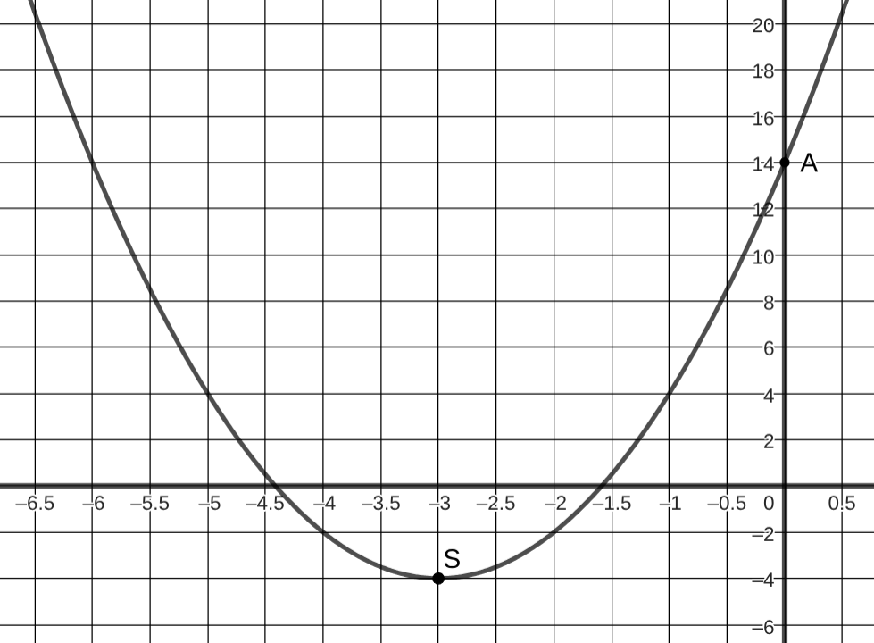

**Solution**

Le point $S(-3;-4)$ est le sommet de la parabole, donc $\alpha=-3$ et $\beta=-4$. Soit $x \in \mathbb{R}$. On a alors $g(x)=a(x+3)^2-4$.

De plus $g(0)=9a-4=14$ donc $a=2$.

Finalement :

$$\begin{align*}
g(x)&=2(x+3)^2-4\\
&=2(x^2+6x+9)-4\\
&=2x^2+12x+18-4\\
&=2x^2+12x+14
\end{align*}$$

**Question 4 (2 points).** Résoudre l’équation :
$$-6x^2+x+2=0$$

**Solution**

$\Delta=1-4\times(-6)\times2=1+48=49$.

$\Delta>0$ donc l’équation admet exactement deux solutions :

$S=\left\{-\dfrac{1}{2};\dfrac{2}{3} \right\}$